# Topología de la red eléctrica: grafo, vecindad eléctrica y exposición por cuadrante

Cindy Carolina Lugo Rozo

2026-09-07

# Introducción

Este documento incorpora la **topología real de la red eléctrica** (`secciones_linea_estructuras`) al panel semana x cuadrante, resolviendo una limitación que quedó documentada en el modelo predictivo: la vecindad usada hasta ahora entre cuadrantes era **geográfica** (`spdep::poly2nb()`, contigüidad de polígonos), pero dos cuadrantes pueden estar lejos en el mapa y sin embargo compartir el mismo circuito eléctrico — o estar geográficamente pegados y no tener ninguna relación eléctrica entre sí.

**Qué aporta esta fuente, en tres niveles:**

1. **Longitud de red por cuadrante** — variable de exposición física más precisa que el conteo de elementos (`n_elementos`): más kilómetros de línea expuestos a intemperie/vegetación/sismos.
2. **Grafo eléctrico real** (`CODIGO_ESTRUCTURA_INICIO`/`CODIGO_ESTRUCTURA_FIN` como aristas) — permite calcular **distancia eléctrica** (metros de cable) entre dos puntos cualesquiera de la red, no solo distancia geográfica en línea recta.
3. **Vecindad eléctrica entre cuadrantes** — reemplaza/complementa la matriz de vecindad geográfica usada en el modelo SAR/SEM: dos cuadrantes son vecinos eléctricos si están conectados en el mismo circuito dentro de un radio de cable dado, independientemente de su distancia geográfica real.

**Hallazgo estructural importante de la fuente:** las filas con `CODIGO_ESTRUCTURA_FIN = NA` no son datos faltantes — marcan **nodos terminales de la red** (el punto donde termina un ramal: típicamente un transformador de distribución final o un remate de línea). En redes de distribución radiales, los tramos terminales suelen acumular más fallas que los tramos cercanos a la subestación (menor redundancia, mayor exposición acumulada de cable). Por eso se separan en una capa propia en vez de descartarse.

## Paquetes

```r
options(repos = c(CRAN = "https://cloud.r-project.org"))

paquetes_red <- c("sf", "dplyr", "tidyr", "ggplot2", "knitr", "kableExtra",
                  "scales", "leaflet", "igraph", "spdep", "purrr", "readr")

invisible(lapply(paquetes_red, function(p) {
  if (!requireNamespace(p, quietly = TRUE)) install.packages(p)
  library(p, character.only = TRUE)
}))
```

```r
# Misma logica que Scripts/Edwin/analisis_correlacion.Rmd.
# Este Rmd vive en Scripts/Cindy/v4/ → el .env de la raiz esta 3 niveles arriba.
env_path <- file.path("..", "..", "..", ".env")
if (file.exists(".env")) {
  readRenviron(".env")
} else if (file.exists(env_path)) {
  readRenviron(env_path)
}

UBICACION_DATA <- Sys.getenv("UBICACION_DATA")
if (UBICACION_DATA == "") {
  stop("UBICACION_DATA no esta definida. Verifica el archivo .env.")
}

cat(sprintf("UBICACION_DATA: %s\n", UBICACION_DATA))
```

```
## UBICACION_DATA: D:/OneDrive - PUJ Cali/Projecto_Grado_Javeriana/Data_Project/
```

```r
DIR_IMAGENES <- file.path(
  UBICACION_DATA, "imagenes", "topologia_red_electrica_cuadrantes_reales"
)
dir.create(DIR_IMAGENES, recursive = TRUE, showWarnings = FALSE)
knitr::opts_chunk$set(
  fig.path = paste0(DIR_IMAGENES, "/"),
  dev = "png"
)
```

## Carga de insumos previos

```r
if (!exists("cuadrantes_infra")) {
  cuadrantes_infra <- st_read(
    file.path(UBICACION_DATA, "infraestructura_cuadrantes_reales.gpkg"),
    layer = "cuadrantes_infra_reales", quiet = TRUE
  )
  cat("cuadrantes_infra recargado desde el .gpkg exportado.\n")
}
```

```
## cuadrantes_infra recargado desde el .gpkg exportado.
```

```r
cuadrantes_infra <- cuadrantes_infra %>%
  mutate(id_cuadrante = as.character(if ("id_cuadrante" %in% names(.)) id_cuadrante else CUADRANTE)) %>%
  st_transform(4326)

if (!exists("centroides_cuadrante_real")) {
  ruta_centroides <- file.path(UBICACION_DATA, "centroides_cuadrantes_reales.csv")
  centroides_cuadrante_real <- readr::read_csv(ruta_centroides, show_col_types = FALSE)
  cat("centroides_cuadrante_real recargado desde CSV.\n")
}
```

```
## centroides_cuadrante_real recargado desde CSV.
```

```r
if (!exists("data_final")) {
  data_final <- readRDS(file.path(UBICACION_DATA, "data_final_modelo_cuadrantes_reales.rds")) %>%
    mutate(id_cuadrante = as.character(id_cuadrante))
  cat("data_final recargado desde el .rds exportado.\n")
}
```

```
## data_final recargado desde el .rds exportado.
```

```r
cat(sprintf("cuadrantes_infra: %d polígonos | data_final: %d filas\n",
            nrow(cuadrantes_infra), nrow(data_final)))
```

```
## cuadrantes_infra: 344 polígonos | data_final: 36120 filas
```

## Carga de la red eléctrica

Ajusta la ruta si `secciones_linea_estructuras` no está ya en el entorno de esta sesión. El archivo fuente usa `;` como separador de columnas (formato regional es-CO), no `,` — por eso se usa `read_delim()` en vez de `read_csv()`.

```r
recargar_secciones <- !exists("secciones_linea_estructuras") ||
  ncol(secciones_linea_estructuras) < 5   # detecta si quedó mal parseado en un intento previo (todo en 1 columna)

if (recargar_secciones) {
  ruta_red <- file.path(UBICACION_DATA, "secciones_linea_estructuras.csv")   # ajustar si el nombre real es distinto

  if (!file.exists(ruta_red)) {
    stop(
      "No se encontró el archivo en: ", ruta_red,
      "\nBusca la ruta real con:\n",
      "  list.files(UBICACION_DATA, pattern = 'secciones|linea|estructura', ignore.case = TRUE, full.names = TRUE)"
    )
  }

  secciones_linea_estructuras <- readr::read_delim(
    ruta_red,
    delim = ";",
    locale = readr::locale(decimal_mark = "."),
    show_col_types = FALSE
  )
}

cat(sprintf("Secciones de línea cargadas: %d filas, %d columnas\n",
            nrow(secciones_linea_estructuras), ncol(secciones_linea_estructuras)))
```

```
## Secciones de línea cargadas: 157511 filas, 13 columnas
```

```r
if (ncol(secciones_linea_estructuras) < 5) {
  stop(
    "El archivo quedó mal parseado (menos de 5 columnas). Verifica el ",
    "separador real abriendo el archivo en un editor de texto plano, y ",
    "ajusta 'delim' en este chunk (';', ',', '\\t')."
  )
}

str(secciones_linea_estructuras)
```

```
## spc_tbl_ [157,511 × 13] (S3: spec_tbl_df/tbl_df/tbl/data.frame)
##  $ NOMBRE_CIRCUITO         : chr [1:157511] "CONSAL_CARMEN" "AGUC5" "TARC1" "MONTESITOS" ...
##  $ CODIGO_SECCION_LINEA    : chr [1:157511] "L131300" "L131283" "L131309" "L131402" ...
##  $ CODIGO_ESTRUCTURA_INICIO: chr [1:157511] "Z302518" "Z302408" "Z302594" "Z302851" ...
##  $ LON_INICIO              : num [1:157511] -73.3 -73.6 -73.1 -73.5 -72.5 ...
##  $ LAT_INICIO              : num [1:157511] 8.61 8.2 8.59 8.19 7.71 ...
##  $ CODIGO_ESTRUCTURA_FIN   : chr [1:157511] NA "Z302408" "Z302595" "EMP72950" ...
##  $ LON_FIN                 : num [1:157511] NA -73.6 -73.1 -73.5 -72.5 ...
##  $ LAT_FIN                 : num [1:157511] NA 8.2 8.59 8.19 7.71 ...
##  $ TENSION                 : num [1:157511] 13.8 13.8 13.8 13.8 13.8 13.8 13.8 13.8 13.8 13.8 ...
##  $ LONGITUD_M              : num [1:157511] 1 1 49.4 241.9 1 ...
##  $ FASES                   : chr [1:157511] "RST" "RS" "RST" "RST" ...
##  $ NODO1_ID                : num [1:157511] 82454654 84394027 84395638 84646650 84414455 ...
##  $ NODO2_ID                : num [1:157511] 0 84394028 84395626 82123992 84414453 ...
##  - attr(*, "spec")=
##   .. cols(
##   ..   NOMBRE_CIRCUITO = col_character(),
##   ..   CODIGO_SECCION_LINEA = col_character(),
##   ..   CODIGO_ESTRUCTURA_INICIO = col_character(),
##   ..   LON_INICIO = col_double(),
##   ..   LAT_INICIO = col_double(),
##   ..   CODIGO_ESTRUCTURA_FIN = col_character(),
##   ..   LON_FIN = col_double(),
##   ..   LAT_FIN = col_double(),
##   ..   TENSION = col_double(),
##   ..   LONGITUD_M = col_double(),
##   ..   FASES = col_character(),
##   ..   NODO1_ID = col_double(),
##   ..   NODO2_ID = col_double()
##   .. )
##  - attr(*, "problems")=<externalptr>
```

# Parte 1 — Separación: tramos de línea vs. nodos terminales

Como se estableció en la exploración inicial, `CODIGO_ESTRUCTURA_FIN` en `NA` indica **fin de ramal**, no dato faltante. Se separan ambos tipos de registro porque cumplen roles distintos en el análisis.

```r
tramos_linea <- secciones_linea_estructuras %>%
  filter(!is.na(LON_FIN), !is.na(LAT_FIN))

nodos_terminales <- secciones_linea_estructuras %>%
  filter(is.na(LON_FIN) | is.na(LAT_FIN)) %>%
  select(
    NOMBRE_CIRCUITO, CODIGO_SECCION_LINEA,
    CODIGO_ESTRUCTURA_INICIO, LON_INICIO, LAT_INICIO,
    NODO1_ID, TENSION, FASES
  )

cat(sprintf(
  "Tramos de línea: %d | Nodos terminales (fin de ramal): %d de %d totales (%.1f%%)\n",
  nrow(tramos_linea), nrow(nodos_terminales), nrow(secciones_linea_estructuras),
  100 * nrow(nodos_terminales) / nrow(secciones_linea_estructuras)
))
```

```
## Tramos de línea: 144774 | Nodos terminales (fin de ramal): 12737 de 157511 totales (8.1%)
```

## Distribución de tensión y fases

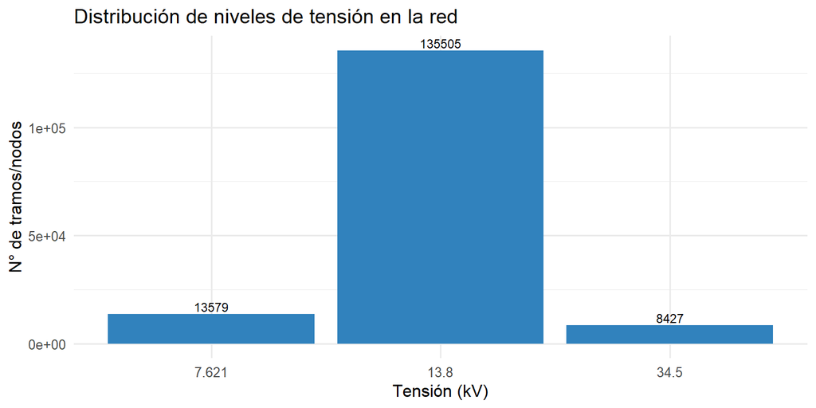

```r
secciones_linea_estructuras %>%
  count(TENSION, sort = TRUE) %>%
  ggplot(aes(x = factor(TENSION), y = n)) +
  geom_col(fill = "#3182bd") +
  geom_text(aes(label = n), vjust = -0.3, size = 3) +
  labs(title = "Distribución de niveles de tensión en la red", x = "Tensión (kV)", y = "N° de tramos/nodos") +
  theme_minimal(base_size = 12)
```

## Circuitos con más tramos (los alimentadores más grandes)

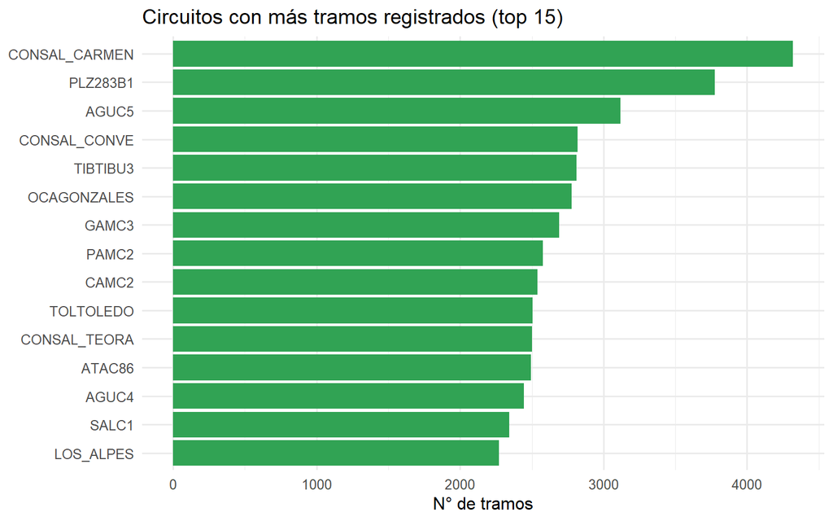

```r
secciones_linea_estructuras %>%
  count(NOMBRE_CIRCUITO, sort = TRUE) %>%
  slice_max(n, n = 15) %>%
  ggplot(aes(x = reorder(NOMBRE_CIRCUITO, n), y = n)) +
  geom_col(fill = "#31a354") +
  coord_flip() +
  labs(title = "Circuitos con más tramos registrados (top 15)", x = NULL, y = "N° de tramos") +
  theme_minimal(base_size = 12)
```

# Parte 2 — Construcción de la geometría de línea

```r
# ------------------------------------------------------------------
# Versión vectorizada: en vez de rowwise() + mutate() (una llamada a
# st_linestring por fila, ~35,000 veces), se construyen todas las
# geometrías en un solo paso usando lapply + do.call, mucho más rápido
# porque evita el overhead de crear un objeto sf por fila individual.
# ------------------------------------------------------------------

datos_validos <- tramos_linea %>%
  filter(
    !is.na(LON_INICIO), !is.na(LAT_INICIO),
    !is.na(LON_FIN), !is.na(LAT_FIN),
    !(LON_INICIO == LON_FIN & LAT_INICIO == LAT_FIN)
  )

cat(sprintf("Construyendo geometría para %d tramos...\n", nrow(datos_validos)))
```

```
## Construyendo geometría para 141407 tramos...
```

```r
# Lista de matrices 2x2 (inicio, fin) — sigue siendo un loop, pero
# sin la sobrecarga de rowwise()/mutate() creando un sf incremental
lista_geometrias <- lapply(seq_len(nrow(datos_validos)), function(i) {
  st_linestring(matrix(
    c(datos_validos$LON_INICIO[i], datos_validos$LAT_INICIO[i],
      datos_validos$LON_FIN[i],    datos_validos$LAT_FIN[i]),
    ncol = 2, byrow = TRUE
  ))
})

tramos_sf <- datos_validos %>%
  st_sf(geometry = st_sfc(lista_geometrias, crs = 4326))

cat(sprintf(
  "Tramos con geometría construida: %d de %d (%.1f%% descartados por coordenadas incompletas o longitud 0)\n",
  nrow(tramos_sf), nrow(tramos_linea),
  100 * (1 - nrow(tramos_sf) / nrow(tramos_linea))
))
```

```
## Tramos con geometría construida: 141407 de 144774 (2.3% descartados por coordenadas incompletas o longitud 0)
```

```r
nodos_terminales_sf <- nodos_terminales %>%
  filter(!is.na(LON_INICIO), !is.na(LAT_INICIO)) %>%
  st_as_sf(coords = c("LON_INICIO", "LAT_INICIO"), crs = 4326, remove = FALSE)
```

## Mapa exploratorio: red y nodos terminales

```r
set.seed(123)

# Muestra de tramos (ajusta el tamaño según qué tan rápido lo quieras)
tramos_muestra <- tramos_sf %>% slice_sample(n = min(4000, nrow(tramos_sf)))

# Muestra proporcional de nodos terminales (menos elementos, pero
# igual pueden ser muchos)
nodos_muestra <- nodos_terminales_sf %>% slice_sample(n = min(1000, nrow(nodos_terminales_sf)))

cat(sprintf("Mostrando muestra: %d de %d tramos | %d de %d nodos terminales\n",
            nrow(tramos_muestra), nrow(tramos_sf),
            nrow(nodos_muestra), nrow(nodos_terminales_sf)))
```

```
## Mostrando muestra: 4000 de 141407 tramos | 1000 de 12499 nodos terminales
```

```r
pal_tension <- colorNumeric("viridis", domain = tramos_sf$TENSION)  # dominio de color con los datos completos, para que la escala sea representativa

leaflet() %>%
  addProviderTiles(providers$CartoDB.Positron) %>%
  addPolygons(
    data = cuadrantes_infra, fillColor = "transparent",
    color = "gray50", weight = 0.5, opacity = 0.5
  ) %>%
  addPolylines(
    data = tramos_muestra, color = ~pal_tension(TENSION), weight = 1.2, opacity = 0.7,
    label = ~paste0(NOMBRE_CIRCUITO, " — ", TENSION, " kV")
  ) %>%
  addCircleMarkers(
    data = nodos_muestra, radius = 2, color = "#de2d26",
    stroke = FALSE, fillOpacity = 0.8,
    label = ~paste0("Nodo terminal — ", NOMBRE_CIRCUITO)
  ) %>%
  addLegend(pal = pal_tension, values = tramos_sf$TENSION, title = "Tensión (kV)", position = "bottomright")
```

[interactive chart not shown]

```r
# pal_tension <- colorNumeric("viridis", domain = tramos_sf$TENSION)
#
# leaflet() %>%
#   addProviderTiles(providers$CartoDB.Positron) %>%
#   addPolygons(
#     data = cuadrantes_infra, fillColor = "transparent",
#     color = "gray50", weight = 0.5, opacity = 0.5
#   ) %>%
#   addPolylines(
#     data = tramos_sf, color = ~pal_tension(TENSION), weight = 1.2, opacity = 0.7,
#     label = ~paste0(NOMBRE_CIRCUITO, " — ", TENSION, " kV")
#   ) %>%
#   addCircleMarkers(
#     data = nodos_terminales_sf, radius = 2, color = "#de2d26",
#     stroke = FALSE, fillOpacity = 0.8,
#     label = ~paste0("Nodo terminal — ", NOMBRE_CIRCUITO)
#   ) %>%
#   addLegend(pal = pal_tension, values = tramos_sf$TENSION, title = "Tensión (kV)", position = "bottomright")
```